# Lecture 4: Singular value decomposition

## Geometric interpretation

The SVD has many possible interpretations and uses. We can visualize the geometry of the SVD using the same 2D picture used to illustrate the induced 2-norm.

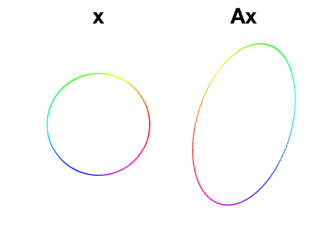

```matlab
A = [-2 0; -1 3];
t = linspace(0,2*pi,300);
x1 = cos(t);  x2 = sin(t);
x = [x1;x2];  Ax = A*x;
subplot(121), scatter(x1,x2,4,t,'.'), axis equal, axis off, title('x')
subplot(122), scatter(Ax(1,:),Ax(2,:),4,t,'.'), axis equal, axis off, title('Ax')
colormap(hsv)
```

The **left singular vectors** and their associated **singular values** are found from the major and minor axes of the ellipse.

```matlab
normAx = sqrt( sum(Ax.^2,1) );  % 2-norms of all the vectors
[sigma1,k1] = max(normAx);  [sigma2,k2] = min(normAx);
sigma = [ sigma1 sigma2 ]
U = [ Ax(:,k1)/sigma1 Ax(:,k2)/sigma2 ]
```

```
sigma =

    3.2566    1.8424


U =

    0.2883    0.9558
    0.9576   -0.2939
```

The **right singular vectors** are the pre-images of those vectors on the ellipse.

```matlab
V = [ x(:,k1) x(:,k2) ]
```

```
V =

   -0.4694   -0.8805
    0.8830   -0.4740
```

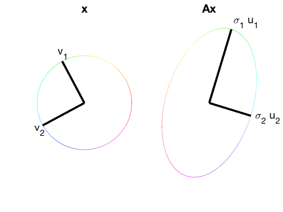

```matlab
subplot(121), scatter(x1,x2,4,t,'.'), axis equal, axis off, title('x')
hold on, plot([0 0; V(1,:)],[0 0; V(2,:)], 'k' )
text(1.2*V(1,:),1.2*V(2,:),{'v_1','v_2'})
subplot(122), scatter(Ax(1,:),Ax(2,:),4,t,'.'), axis equal, axis off, title('Ax')
hold on, plot([0 0; U(1,:).*sigma],[0 0; U(2,:).*sigma], 'k' )
text(1.1*U(1,:).*sigma,1.1*U(2,:).*sigma,{'\sigma_1 u_1','\sigma_2 u_2'})
colormap(hsv)
```

Having searched over only a finite number of vectors, we have approximately (up to choices of signs in the singular vectors) found the SVD of this matrix.

```matlab
[U,S,V] = svd(A)
```

```
U =

    0.2898    0.9571
    0.9571   -0.2898


S =

    3.2566         0
         0    1.8424


V =

   -0.4719   -0.8817
    0.8817   -0.4719
```

## Full versus thin

In the case of a rectangular matrix, some of the SVD is essentially dead weight. We consider (as always in this text) the case with $m>n$, a tall and skinny matrix. The range of $A$ can have at most only $n$ dimensions. The last $m-n$ columns of $U$ therefore describe the remainder of $\mathbb{C}^m$ in which the range is embedded (i.e., the orthogonal complement). That description can be changed without affecting the matrix at all.

Algebraically, we have

$$U = \bigl[ U_1 \: U_2 \bigr], \qquad S = \begin{bmatrix} S_1 \\ 0 \end{bmatrix},$$

where the breaks occur after $n$ columns in $U$ and $n$ rows in $S$. Therefore $US=U_1S_1$, and we change nothing by replacing the SVD with $U_1S_1V^*$. The book calls this the **reduced SVD**, though it is also called the **thin SVD**.

```matlab
A = rand(4,3);
[U,S,V] = svd(A)       % full SVD
[U1,S1,V] = svd(A,0)   % thin SVD
```

```
U =

  -4.2591e-01  -4.2726e-01  -1.9420e-01   7.7352e-01
  -3.6192e-01   1.8280e-01   9.0498e-01   1.2889e-01
  -6.8998e-01  -3.6876e-01  -1.1424e-01  -6.1229e-01
  -4.5994e-01   8.0501e-01  -3.6090e-01   1.0080e-01


S =

   1.8437e+00            0            0
            0   7.1187e-01            0
            0            0   1.7062e-01
            0            0            0


V =

  -5.8697e-01  -7.8890e-01   1.8195e-01
  -6.6113e-01   3.3734e-01  -6.7016e-01
  -4.6731e-01   5.1366e-01   7.1957e-01


U1 =

  -4.2591e-01  -4.2726e-01  -1.9420e-01
  -3.6192e-01   1.8280e-01   9.0498e-01
  -6.8998e-01  -3.6876e-01  -1.1424e-01
  -4.5994e-01   8.0501e-01  -3.6090e-01


S1 =

   1.8437e+00            0            0
            0   7.1187e-01            0
            0            0   1.7062e-01


V =

  -5.8697e-01  -7.8890e-01   1.8195e-01
  -6.6113e-01   3.3734e-01  -6.7016e-01
  -4.6731e-01   5.1366e-01   7.1957e-01
```

The price we pay is that while the columns of $U_1$ are orthonormal, we can't call it a unitary matrix because it isn't square. Take note:

```matlab
U1'*U1    % n by n identity
U1*U1'    % NOT the m by m identity
```

[output not shown]

We'll discuss the significance of $U_1U_1^*$ in due course.